# Analiza rynku mieszkaniowego w Polsce

## Opis zbioru danych

Zbiór danych obejmuje oferty sprzedaży i wynajmu mieszkań z 15 największych miast w Polsce (m.in. Warszawa, Kraków, Wrocław, Poznań, Gdańsk, Szczecin, Łódź, Lublin, Katowice, Białystok, Bydgoszcz, Częstochowa). Dane pochodzą z lokalnych serwisów ogłoszeniowych i zostały wzbogacone o informacje przestrzenne z OpenStreetMap, takie jak odległości do szkół, przedszkoli, przychodni, restauracji czy aptek. Zakres czasowy: 08.2023 – 06.2024, aktualizacje miesięczne.

Zawartość danych obejmuje cechy mieszań takie jak:

- `city` — miasto,
- `type` — typ budynku,
- `squareMeters` — powierzchnia,
- `rooms` — liczba pokoi,
- `floor`, `floorCount` — piętro i liczba pięter,
- `buildYear` — rok budowy,
- `latitude`, `longitude` — współrzędne,
- `centreDistance` — odległość od centrum,
- `poiCount` — liczba punktów usługowych w promieniu 500m,
- `ownership` — forma własności,
- `condition` — stan mieszkania,
- `hasParkingSpace`, `hasBalcony`, `hasElevator`, `hasSecurity`, `hasStorageRoom` - dodatkowe udogodnienia,
- `price` — cena ofertowa (sprzedaż lub czynsz miesięczny).

## 1. Wczytanie danych

Celem tego etapu jest przygotowanie danych do dalszej analizy. Sprawdzamy:

- czy pliki surowe wczytały się poprawnie,
- czy mają spójną strukturę,
- ile rekordów i kolumn zawiera każdy plik,
- oraz czy występują powtarzające się ogłoszenia między miesiącami.

```
Pierwszy plik: apartments_pl_2023_08.csv
Rozmiar: 18905 wierszy, 28 kolumn
```

|  | id | city | type | squareMeters | rooms | floor | floorCount | buildYear | latitude | longitude | ... | pharmacyDistance | ownership | buildingMaterial | condition | hasParkingSpace | hasBalcony | hasElevator | hasSecurity | hasStorageRoom | price |
| --- | --- | --- | --- | --- | --- | --- | --- | --- | --- | --- | --- | --- | --- | --- | --- | --- | --- | --- | --- | --- | --- |
| 0 | f8524536d4b09a0c8ccc0197ec9d7bde | szczecin | blockOfFlats | 63.00 | 3.0 | 4.0 | 10.0 | 1980.0 | 53.378933 | 14.625296 | ... | 0.413 | condominium | concreteSlab | NaN | yes | yes | yes | no | yes | 415000 |
| 1 | accbe77d4b360fea9735f138a50608dd | szczecin | blockOfFlats | 36.00 | 2.0 | 8.0 | 10.0 | NaN | 53.442692 | 14.559690 | ... | 0.205 | cooperative | concreteSlab | NaN | no | yes | yes | no | yes | 395995 |
| 2 | 8373aa373dbc3fe7ca3b7434166b8766 | szczecin | tenement | 73.02 | 3.0 | 2.0 | 3.0 | NaN | 53.452222 | 14.553333 | ... | 0.280 | condominium | brick | NaN | no | no | no | no | no | 565000 |
| 3 | 0a68cd14c44ec5140143ece75d739535 | szczecin | tenement | 87.60 | 3.0 | 2.0 | 3.0 | NaN | 53.435100 | 14.532900 | ... | 0.087 | condominium | brick | NaN | yes | yes | no | no | yes | 640000 |
| 4 | f66320e153c2441edc0fe293b54c8aeb | szczecin | blockOfFlats | 66.00 | 3.0 | 1.0 | 3.0 | NaN | 53.410278 | 14.503611 | ... | 0.514 | condominium | NaN | NaN | no | no | no | no | no | 759000 |

5 rows × 28 columns

```
(18905, 28)
```

```
<class 'pandas.DataFrame'>
RangeIndex: 18905 entries, 0 to 18904
Data columns (total 28 columns):
 #   Column                Non-Null Count  Dtype
---  ------                --------------  -----
 0   id                    18905 non-null  str
 1   city                  18905 non-null  str
 2   type                  14866 non-null  str
 3   squareMeters          18905 non-null  float64
 4   rooms                 18905 non-null  float64
 5   floor                 15467 non-null  float64
 6   floorCount            18643 non-null  float64
 7   buildYear             15634 non-null  float64
 8   latitude              18905 non-null  float64
 9   longitude             18905 non-null  float64
```

[output cut: 20 more lines]

Sprawdzamy, czy wszystkie pliki sprzedażowe mają taki sam układ.

|  | plik | wiersze | kolumny | pierwsza_kolumna | ostatnia_kolumna | czy_spojne |
| --- | --- | --- | --- | --- | --- | --- |
| 0 | apartments_pl_2023_08.csv | 18905 | 28 | id | price | True |
| 1 | apartments_pl_2023_09.csv | 16997 | 28 | id | price | True |
| 2 | apartments_pl_2023_10.csv | 16690 | 28 | id | price | True |
| 3 | apartments_pl_2023_11.csv | 16302 | 28 | id | price | True |
| 4 | apartments_pl_2023_12.csv | 16483 | 28 | id | price | True |
| 5 | apartments_pl_2024_01.csv | 15521 | 28 | id | price | True |
| 6 | apartments_pl_2024_02.csv | 16361 | 28 | id | price | True |
| 7 | apartments_pl_2024_03.csv | 17318 | 28 | id | price | True |
| 8 | apartments_pl_2024_04.csv | 19259 | 28 | id | price | True |
| 9 | apartments_pl_2024_05.csv | 20231 | 28 | id | price | True |
| 10 | apartments_pl_2024_06.csv | 21501 | 28 | id | price | True |

Przechodzimy do połączenia 11 miesięcy sprzedaży w jeden zbiór.

Sprawdzamy liczbę wierszy i kolumn

```
(195568, 29)
```

|  | id | city | type | squareMeters | rooms | floor | floorCount | buildYear | latitude | longitude | ... | ownership | buildingMaterial | condition | hasParkingSpace | hasBalcony | hasElevator | hasSecurity | hasStorageRoom | price | month |
| --- | --- | --- | --- | --- | --- | --- | --- | --- | --- | --- | --- | --- | --- | --- | --- | --- | --- | --- | --- | --- | --- |
| 0 | f8524536d4b09a0c8ccc0197ec9d7bde | szczecin | blockOfFlats | 63.00 | 3.0 | 4.0 | 10.0 | 1980.0 | 53.378933 | 14.625296 | ... | condominium | concreteSlab | NaN | yes | yes | yes | no | yes | 415000 | 2023_08 |
| 1 | accbe77d4b360fea9735f138a50608dd | szczecin | blockOfFlats | 36.00 | 2.0 | 8.0 | 10.0 | NaN | 53.442692 | 14.559690 | ... | cooperative | concreteSlab | NaN | no | yes | yes | no | yes | 395995 | 2023_08 |
| 2 | 8373aa373dbc3fe7ca3b7434166b8766 | szczecin | tenement | 73.02 | 3.0 | 2.0 | 3.0 | NaN | 53.452222 | 14.553333 | ... | condominium | brick | NaN | no | no | no | no | no | 565000 | 2023_08 |
| 3 | 0a68cd14c44ec5140143ece75d739535 | szczecin | tenement | 87.60 | 3.0 | 2.0 | 3.0 | NaN | 53.435100 | 14.532900 | ... | condominium | brick | NaN | yes | yes | no | no | yes | 640000 | 2023_08 |
| 4 | f66320e153c2441edc0fe293b54c8aeb | szczecin | blockOfFlats | 66.00 | 3.0 | 1.0 | 3.0 | NaN | 53.410278 | 14.503611 | ... | condominium | NaN | NaN | no | no | no | no | no | 759000 | 2023_08 |

5 rows × 29 columns

```
month
2023_08    18905
2023_09    16997
2023_10    16690
2023_11    16302
2023_12    16483
2024_01    15521
2024_02    16361
2024_03    17318
2024_04    19259
2024_05    20231
2024_06    21501
Name: count, dtype: int64
```

Upewniamy się, że typy danych to nadal liczby

```
<class 'pandas.DataFrame'>
RangeIndex: 195568 entries, 0 to 195567
Data columns (total 29 columns):
 #   Column                Non-Null Count   Dtype
---  ------                --------------   -----
 0   id                    195568 non-null  str
 1   city                  195568 non-null  str
 2   type                  153307 non-null  str
 3   squareMeters          195568 non-null  float64
 4   rooms                 195568 non-null  float64
 5   floor                 160974 non-null  float64
 6   floorCount            193185 non-null  float64
 7   buildYear             163352 non-null  float64
 8   latitude              195568 non-null  float64
 9   longitude             195568 non-null  float64
```

[output cut: 21 more lines]

Sprawdzamy duplikaty (jeżeli mieszkanie było wystawione kilka miesięcy z rzędu to jego id może się pojawić kilka razy).

```
Liczba powtarzających się wpisów: 102,601
Liczba unikalnych identyfikatorów: 92,967
Udział powtórzeń: 52.46%
```

Sprawdzamy liczbę mieszkań.

```
92967
```

Sprawdzamy liczbę wszystkich wierszy.

```
195568
```

Wniosek: część ofert się powtarza w kolejnych miesiącach.

Następnie weryfikujemy duplikaty w danych.

```
18905    71de9eb8a92ac12d7c94315228b70cfb
Name: id, dtype: str
```

|  | id | city | type | squareMeters | rooms | floor | floorCount | buildYear | latitude | longitude | ... | ownership | buildingMaterial | condition | hasParkingSpace | hasBalcony | hasElevator | hasSecurity | hasStorageRoom | price | month |
| --- | --- | --- | --- | --- | --- | --- | --- | --- | --- | --- | --- | --- | --- | --- | --- | --- | --- | --- | --- | --- | --- |
| 282 | 71de9eb8a92ac12d7c94315228b70cfb | szczecin | tenement | 123.45 | 4.0 | 2.0 | 3.0 | NaN | 53.432586 | 14.535685 | ... | condominium | brick | NaN | no | yes | no | no | yes | 799000 | 2023_08 |
| 18905 | 71de9eb8a92ac12d7c94315228b70cfb | szczecin | tenement | 123.45 | 4.0 | 2.0 | 3.0 | NaN | 53.432586 | 14.535685 | ... | condominium | brick | NaN | no | yes | no | no | yes | 799000 | 2023_09 |
| 36204 | 71de9eb8a92ac12d7c94315228b70cfb | szczecin | tenement | 123.45 | 4.0 | 2.0 | 3.0 | NaN | 53.432586 | 14.535685 | ... | condominium | brick | NaN | no | yes | no | no | yes | 799000 | 2023_10 |
| 52944 | 71de9eb8a92ac12d7c94315228b70cfb | szczecin | tenement | 123.45 | 4.0 | 2.0 | 3.0 | NaN | 53.432586 | 14.535685 | ... | condominium | brick | NaN | no | yes | no | no | yes | 799000 | 2023_11 |

4 rows × 29 columns

### Podsumowanie wczytywania danych

- Pliki źródłowe są spójne pod względem liczby kolumn i struktury.
- Połączenie 11 miesięcy pozwala uzyskać pełny zbiór sprzedaży z okresu 2023-08 do 2024-06.
- W zbiorze występują powtarzające się identyfikatory ofert, co jest oczekiwane przy wystawianiu tych samych mieszkań w kolejnych miesiącach.
- W kolejnych etapach warto uwzględnić te powtórzenia przy analizie trendów cenowych oraz przy przygotowaniu danych do modelowania.

# 2. Czyszczenie danych

Celem tego etapu jest przygotowanie zbioru danych do dalszej analizy poprzez:

- identyfikację braków danych,
- ocenę typów zmiennych i ich spójności,
- wykrycie potencjalnych wartości odstających,
- określenie mechanizmów braków (MCAR/MAR/MNAR),
- zaplanowanie i wdrożenie strategii imputacji.

Po wczytaniu danych pierwszym krokiem jest ocena ich kompletności. Analiza braków pozwala zidentyfikować zmienne problematyczne oraz określić, które z nich wymagają imputacji, a które mogą zostać usunięte.

|  | missing_percent |
| --- | --- |
| condition | 74.81% |
| buildingMaterial | 39.57% |
| type | 21.61% |
| floor | 17.69% |
| buildYear | 16.47% |
| hasElevator | 4.96% |
| collegeDistance | 2.78% |
| floorCount | 1.22% |
| clinicDistance | 0.37% |
| restaurantDistance | 0.24% |
| pharmacyDistance | 0.14% |
| postOfficeDistance | 0.13% |
| kindergartenDistance | 0.11% |
| schoolDistance | 0.09% |

Po zidentyfikowaniu kolumn z największą liczbą braków przechodzimy do oceny struktury zbioru. Sprawdzamy typy zmiennych oraz liczbę niepustych wartości, aby upewnić się, że dane są poprawnie wczytane i gotowe do dalszej diagnostyki.

|  | dtype | non_null | null |
| --- | --- | --- | --- |
| condition | str | 49261 | 146307 |
| buildingMaterial | str | 118186 | 77382 |
| type | str | 153307 | 42261 |
| floor | float64 | 160974 | 34594 |
| buildYear | float64 | 163352 | 32216 |
| hasElevator | str | 185866 | 9702 |
| collegeDistance | float64 | 190132 | 5436 |
| floorCount | float64 | 193185 | 2383 |
| clinicDistance | float64 | 194840 | 728 |
| restaurantDistance | float64 | 195089 | 479 |
| pharmacyDistance | float64 | 195291 | 277 |
| postOfficeDistance | float64 | 195320 | 248 |
| kindergartenDistance | float64 | 195361 | 207 |
| schoolDistance | float64 | 195400 | 168 |
| centreDistance | float64 | 195568 | 0 |
| longitude | float64 | 195568 | 0 |
| latitude | float64 | 195568 | 0 |
| id | str | 195568 | 0 |
| city | str | 195568 | 0 |
| squareMeters | float64 | 195568 | 0 |
| rooms | float64 | 195568 | 0 |
| poiCount | float64 | 195568 | 0 |
| ownership | str | 195568 | 0 |
| hasParkingSpace | str | 195568 | 0 |
| hasBalcony | str | 195568 | 0 |
| hasSecurity | str | 195568 | 0 |
| hasStorageRoom | str | 195568 | 0 |
| price | int64 | 195568 | 0 |
| month | str | 195568 | 0 |

Znając strukturę danych, możemy teraz określić ich skalę. Liczba rekordów i zmiennych pozwala ocenić złożoność zbioru oraz potencjalne wyzwania związane z czyszczeniem i imputacją.

```
Liczba rekordów: 195,568
Liczba zmiennych: 29
```

Zbiór danych zawiera dużą liczbę obserwacji, co umożliwia przeprowadzenie wiarygodnej analizy statystycznej. Kolejnym krokiem jest analiza statystyk opisowych zmiennych numerycznych. Pozwala to ocenić rozkłady, wykryć wartości odstające oraz zrozumieć ogólną charakterystykę danych liczbowych.

|  | count | mean | std | min | 25% | 50% | 75% | max |
| --- | --- | --- | --- | --- | --- | --- | --- | --- |
| squareMeters | 195568.000000 | 58.700000 | 21.410000 | 25.000000 | 44.000000 | 54.600000 | 68.550000 | 150.000000 |
| rooms | 195568.000000 | 2.680000 | 0.920000 | 1.000000 | 2.000000 | 3.000000 | 3.000000 | 6.000000 |
| floor | 160974.000000 | 3.330000 | 2.530000 | 1.000000 | 2.000000 | 3.000000 | 4.000000 | 29.000000 |
| floorCount | 193185.000000 | 5.310000 | 3.310000 | 1.000000 | 3.000000 | 4.000000 | 6.000000 | 29.000000 |
| buildYear | 163352.000000 | 1985.980000 | 33.810000 | 1850.000000 | 1967.000000 | 1994.000000 | 2016.000000 | 2024.000000 |
| latitude | 195568.000000 | 52.030000 | 1.340000 | 49.980000 | 51.110000 | 52.190000 | 52.410000 | 54.610000 |
| longitude | 195568.000000 | 19.470000 | 1.780000 | 14.450000 | 18.520000 | 19.900000 | 20.990000 | 23.210000 |
| centreDistance | 195568.000000 | 4.350000 | 2.840000 | 0.010000 | 2.010000 | 3.980000 | 6.150000 | 16.940000 |
| poiCount | 195568.000000 | 20.670000 | 24.330000 | 0.000000 | 7.000000 | 14.000000 | 24.000000 | 212.000000 |
| schoolDistance | 195400.000000 | 0.410000 | 0.460000 | 0.000000 | 0.180000 | 0.290000 | 0.470000 | 4.950000 |
| clinicDistance | 194840.000000 | 0.970000 | 0.890000 | 0.000000 | 0.360000 | 0.680000 | 1.240000 | 5.000000 |
| postOfficeDistance | 195320.000000 | 0.520000 | 0.500000 | 0.000000 | 0.240000 | 0.390000 | 0.620000 | 4.970000 |
| kindergartenDistance | 195361.000000 | 0.370000 | 0.440000 | 0.000000 | 0.160000 | 0.260000 | 0.420000 | 4.960000 |
| restaurantDistance | 195089.000000 | 0.350000 | 0.460000 | 0.000000 | 0.110000 | 0.230000 | 0.410000 | 4.990000 |
| collegeDistance | 190132.000000 | 1.440000 | 1.100000 | 0.000000 | 0.580000 | 1.120000 | 2.060000 | 5.000000 |
| pharmacyDistance | 195291.000000 | 0.360000 | 0.460000 | 0.000000 | 0.140000 | 0.240000 | 0.410000 | 4.990000 |
| price | 195568.000000 | 784183.300000 | 409709.230000 | 150000.000000 | 520000.000000 | 699000.000000 | 930000.000000 | 3250000.000000 |

Statystyki opisowe zmiennych numerycznych ujawniają podstawowe właściwości danych, takie jak zakres wartości, średnia, mediana oraz rozrzut. Pozwala to wstępnie ocenić rozkłady zmiennych oraz wykryć potencjalne wartości odstające. W analizowanych danych nie widać nieścisłości. Po analizie zmiennych numerycznych przechodzimy do zmiennych kategorycznych. Ich struktura i najczęściej występujące wartości są kluczowe przy planowaniu dalszego czyszczenia oraz przygotowywaniu danych do modelowania.

|  | count | unique | top | freq |
| --- | --- | --- | --- | --- |
| id | 195568 | 92967 | d59165364f1c4b3d658890e808e7d77c | 11 |
| city | 195568 | 15 | warszawa | 59246 |
| type | 153307 | 3 | blockOfFlats | 91368 |
| ownership | 195568 | 3 | condominium | 176123 |
| buildingMaterial | 118186 | 2 | brick | 91899 |
| condition | 49261 | 2 | premium | 27869 |
| hasParkingSpace | 195568 | 2 | no | 142410 |
| hasBalcony | 195568 | 2 | yes | 112049 |
| hasElevator | 185866 | 2 | no | 93662 |
| hasSecurity | 195568 | 2 | no | 173630 |
| hasStorageRoom | 195568 | 2 | no | 110583 |
| month | 195568 | 11 | 2024_06 | 21501 |

Statystyki zmiennych kategorycznych pokazują najczęściej występujące wartości oraz liczbę unikalnych kategorii. Informacje te są kluczowe przy planowaniu dalszego czyszczenia danych oraz przygotowywaniu zmiennych do modelowania. Aby lepiej zrozumieć rozmieszczenie braków w zbiorze, wizualizujemy je za pomocą narzędzi missingno. Pozwala to ocenić, czy braki są losowe, czy też tworzą wyraźne wzorce.

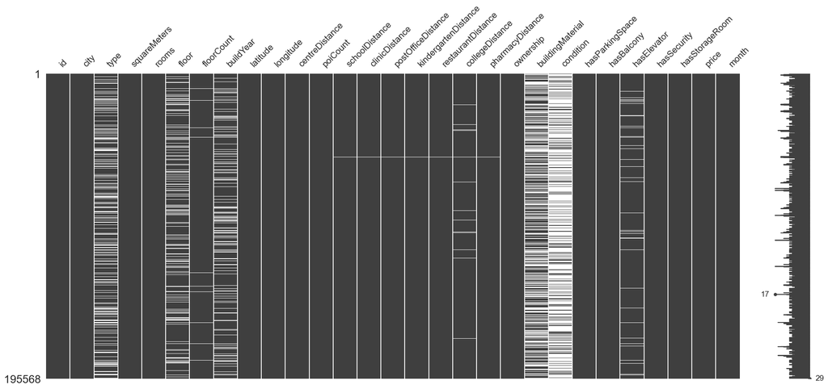

Część braków występuje w konkretnych kolumnach. Jednak sama wizualizacja rozmieszczenia braków nie wystarcza — ważne jest również sprawdzenie, czy braki współwystępują między zmiennymi. W tym celu analizujemy korelację braków.

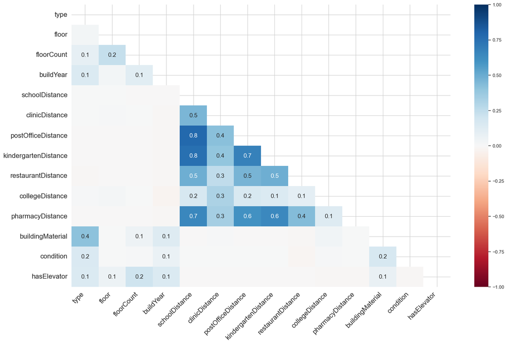

Na podstawie wizualizacji i korelacji braków możemy przejść do szczegółowej analizy mechanizmów braków w poszczególnych zmiennych. Pozwoli to określić, które braki są losowe (MCAR), zależne od innych zmiennych (MAR), a które wynikają z celowego pomijania informacji (MNAR).

**Condition** - sporo braków - to raczej nie jest przykładowy brak techniczny. Stan mieszkania może być informacją, którą sprzedający może nie podawać. Możemy mieć do czynienia z MNAR (Missing Not At Random): mieszkanie w dobrym stanie - właściciel wpisuje, mieszkanie wymagające remontu - właściciel pomija fakt. Ta zmienna nie nadaje się do imputacji.

**BuildingMaterial** - prawdopodobnie zależy od typu nieruchomości. Sprawdzamy procent braków w obrębie typu nieruchomości. Szukamy odpowiedzi na pytanie "Dla każdego typu mieszkania: jaki procent rekordów ma podany materiał budynku, a jaki procent ma brak?".

| buildingMaterial type | False | True |
| --- | --- | --- |
| apartmentBuilding | 100.0% | 0.0% |
| blockOfFlats | 51.3% | 48.7% |
| tenement | 100.0% | 0.0% |

Wszystkie rekordy apartmentBuilding i tenement nie mają braków. Wszystkie braki danych tej zmiennej pochodzą z blockOfFlats (48,7% mieszkań). Brak jest zależny od innej zmiennej (type) - mechanizm MAR (Missing at Random).

**Type** - wydaje się losowy. Tutaj możemy prawdopodobnie imputować modą albo stworzyć kategorię Unknwown.

**Floor i FloorCount** - czy braki korelują ze sobą? Jeśli braki w floor pokrywają się z brakami w floorCount, to może to być MAR (wspólna przyczyna). Jeśli są rozproszone niezależnie, to MCAR (losowe).

| floorCount floor | False | True | All |
| --- | --- | --- | --- |
| False | 160974 | 0 | 160974 |
| True | 32211 | 2383 | 34594 |
| All | 193185 | 2383 | 195568 |

Nigdy nie ma sytuacji, że floor jest, a floorCount brakuje. 32211 rekordów - gdy floor brakuje, ale floorCount jest (prawie 94% z brakami floor). 2383 rekordy - gdy oba brakują (prawie 7% z brakami floor). To jest MAR (Missing At Random). Braki nie są losowe - są powiązane. Gdy brakuje floor, zwykle floorCount jest dostępny (może być wspólna przyczyna). W ramach czyszczenia danych, tam gdzie floor brakuje ale floorCount jest - można imputować floor z floorCount lub średnią wg typu. Gdzie oba brakują (2383) - usunąć lub imputować ostrożniej.

**BuildYear** - czy braki są zależne od typu nieruchomości?

| buildYear type | False | True |
| --- | --- | --- |
| apartmentBuilding | 93.2% | 6.8% |
| blockOfFlats | 86.0% | 14.0% |
| tenement | 80.3% | 19.7% |

Kamienice (tenement) mają ~20% braków - to najstarsza zabudowa, może nie mieć dokumentacji roku budowy. Bloki mieszkalne mają 14% braków - pośrednio. Budynki apartamentowe mają najmniej braków (7%) - to nowsze/lepiej udokumentowane. To nie jest losowe - to MAR. Braki zależą od typu nieruchomości. Można imputować buildYear medianą lub trybem wg typu (bo MAR i imputacja wg grupy jest uzasadniona).

**hasElevator** - czy braki są zależne od typu nieruchomości?

| hasElevator type | False | True |
| --- | --- | --- |
| apartmentBuilding | 99.3% | 0.7% |
| blockOfFlats | 97.1% | 2.9% |
| tenement | 92.5% | 7.5% |

Bloki mieszkalne (blockOfFlats) mają 2.9% braków w hasElevator, kamienice (tenement) 7.5%, a budynki apartamentowe (apartmentBuilding) tylko 0.7%. To pokazuje wyraźny wzorzec: braki rosną wraz z typem zabudowy, a najwięcej braków występuje w kamienicach.

To sugeruje zależność braków od typu nieruchomości, choć jest ona słabsza niż w przypadku buildYear. Sprawdzamy powiązanie braków z brakami w innych zmiennych.

```
Z 9702 rekordów z brakami w hasElevator:

  condition            - braki:  7032 ( 72.5%)
  buildingMaterial     - braki:  5437 ( 56.0%)
  buildYear            - braki:  3814 ( 39.3%)
  floor                - braki:  2672 ( 27.5%)
  floorCount           - braki:  1066 ( 11.0%)
```

Wyraźnie widać, że braki w hasElevator są powiązane z brakami w condition (72.5%), buildingMaterial (56%) i buildYear (39.3%). To nie są niezależne braki losowe. Dla mieszkań bez informacji o windzie często jednocześnie brakuje danych o stanie, materiale i roku budowy budynku.

**Wniosek:** Braki w hasElevator pochodzą z tego samego źródła co braki w charakterystykach budynku - to niekompletne dane od ogłoszeniodawcy lub braki w bazie źródłowej. Można je traktować jako MAR (Missing At Random) warunkowe względem typu nieruchomości. Dla imputacji można rozważyć median/modę wg typu zabudowy.

Teraz analizujemy wszystkie kolumny typu `*Distance` razem: `collegeDistance`, `clinicDistance`, `restaurantDistance`, `pharmacyDistance`, `postOfficeDistance`, `kindergartenDistance` i `schoolDistance`. Sprawdzimy:

- ile braków jest w każdej kolumnie,
- czy braki współwystępują między kolumnami distance,
- oraz czy występują wzorce braków zależne od typu nieruchomości.

Braki w kolumnach distance (%)

|  | missing_percent |
| --- | --- |
| collegeDistance | 2.78% |
| clinicDistance | 0.37% |
| restaurantDistance | 0.24% |
| pharmacyDistance | 0.14% |
| postOfficeDistance | 0.13% |
| kindergartenDistance | 0.11% |
| schoolDistance | 0.09% |

Korelacja braków między kolumnami distance

|  | collegeDistance | clinicDistance | restaurantDistance | pharmacyDistance | postOfficeDistance | kindergartenDistance | schoolDistance |
| --- | --- | --- | --- | --- | --- | --- | --- |
| collegeDistance | 1.000000 | 0.320000 | 0.100000 | 0.130000 | 0.160000 | 0.140000 | 0.170000 |
| clinicDistance | 0.320000 | 1.000000 | 0.260000 | 0.340000 | 0.420000 | 0.400000 | 0.460000 |
| restaurantDistance | 0.100000 | 0.260000 | 1.000000 | 0.430000 | 0.460000 | 0.490000 | 0.490000 |
| pharmacyDistance | 0.130000 | 0.340000 | 0.430000 | 1.000000 | 0.610000 | 0.640000 | 0.650000 |
| postOfficeDistance | 0.160000 | 0.420000 | 0.460000 | 0.610000 | 1.000000 | 0.680000 | 0.790000 |
| kindergartenDistance | 0.140000 | 0.400000 | 0.490000 | 0.640000 | 0.680000 | 1.000000 | 0.750000 |
| schoolDistance | 0.170000 | 0.460000 | 0.490000 | 0.650000 | 0.790000 | 0.750000 | 1.000000 |

Procent braków distance wg typu nieruchomości

| type | collegeDistance | clinicDistance | restaurantDistance | pharmacyDistance | postOfficeDistance | kindergartenDistance | schoolDistance |
| --- | --- | --- | --- | --- | --- | --- | --- |
| apartmentBuilding | 2.81% | 0.57% | 0.49% | 0.23% | 0.20% | 0.23% | 0.13% |
| blockOfFlats | 3.38% | 0.38% | 0.14% | 0.16% | 0.12% | 0.09% | 0.08% |
| tenement | 0.36% | 0.07% | 0.42% | 0.06% | 0.07% | 0.03% | 0.02% |

Analiza braków w zmiennych odległościowych potwierdza, że braki te mają charakter MAR i współwystępują między kolumnami. Uzasadnia to zastosowanie wielowymiarowej imputacji, która uwzględnia zależności między zmiennymi.

## Podsumowanie

Na podstawie przeprowadzonej diagnostyki opracowano strategię czyszczenia danych, obejmującą usunięcie jednej zmiennej, imputację zmiennych zależnych (MAR) oraz zastosowanie wielowymiarowej imputacji dla zmiennych odległościowych.

W ramach czyszczenia danych:

- usunięto zmienną `condition` (MNAR, 75% braków),
- imputowano `buildingMaterial` metodą hot‑deck dla blockOfFlats,
- imputowano `floor` z `floorCount`,
- imputowano zmienne liczbowe medianą wg typu,
- imputowano zmienne kategoryczne jako `Unknown`,
- zastosowano IterativeImputer dla zmiennych distance,
- zapisano finalny zbiór `sales_clean.csv`.

Zbiór jest kompletny i gotowy do dalszej analizy.

```
Zapisano 195568 rekordów do ..\Dane\Czyste\sales_clean.csv
Pozostałe braki: 0
```

Po wykonaniu wszystkich kroków czyszczenia zbiór danych jest kompletny, spójny i gotowy do dalszej analizy. Oczyszczony zbiór zapisano do pliku `sales_clean.csv`, który stanowi podstawę do kolejnych etapów analizy.

# 3. Analiza opisowa

Celem etapu jest przedstawienie charakterystyki zbioru danych po procesie czyszczenia i imputacji braków. Analiza opisowa stanowi fundament dalszych etapów pracy, ponieważ pozwala zrozumieć strukturę danych, ich rozkłady, zależności oraz potencjalne ograniczenia.

W pierwszym kroku sprawdzamy podstawowe informacje o zbiorze danych po procesie czyszczenia i imputacji. Weryfikujemy liczbę obserwacji i zmiennych, typy danych oraz ogólną strukturę zbioru. Pozwala to zweryfikować poprawność przygotowania danych oraz określić, które zmienne będą analizowane w kolejnych etapach.

W pierwszym kroku analizujemy strukturę zbioru danych po czyszczeniu, aby upewnić się, że dane są kompletne i gotowe do dalszej eksploracji.

|  | dtype | non_null | null | missing_percent |
| --- | --- | --- | --- | --- |
| id | str | 195568 | 0 | 0.00% |
| city | str | 195568 | 0 | 0.00% |
| type | str | 195568 | 0 | 0.00% |
| squareMeters | float64 | 195568 | 0 | 0.00% |
| rooms | float64 | 195568 | 0 | 0.00% |
| floor | float64 | 195568 | 0 | 0.00% |
| floorCount | float64 | 195568 | 0 | 0.00% |
| buildYear | float64 | 195568 | 0 | 0.00% |
| latitude | float64 | 195568 | 0 | 0.00% |
| longitude | float64 | 195568 | 0 | 0.00% |
| centreDistance | float64 | 195568 | 0 | 0.00% |
| poiCount | float64 | 195568 | 0 | 0.00% |
| schoolDistance | float64 | 195568 | 0 | 0.00% |
| clinicDistance | float64 | 195568 | 0 | 0.00% |
| postOfficeDistance | float64 | 195568 | 0 | 0.00% |
| kindergartenDistance | float64 | 195568 | 0 | 0.00% |
| restaurantDistance | float64 | 195568 | 0 | 0.00% |
| collegeDistance | float64 | 195568 | 0 | 0.00% |
| pharmacyDistance | float64 | 195568 | 0 | 0.00% |
| ownership | str | 195568 | 0 | 0.00% |
| buildingMaterial | str | 195568 | 0 | 0.00% |
| hasParkingSpace | str | 195568 | 0 | 0.00% |
| hasBalcony | str | 195568 | 0 | 0.00% |
| hasElevator | str | 195568 | 0 | 0.00% |
| hasSecurity | str | 195568 | 0 | 0.00% |
| hasStorageRoom | str | 195568 | 0 | 0.00% |
| price | int64 | 195568 | 0 | 0.00% |
| month | str | 195568 | 0 | 0.00% |

Zbiór danych po procesie czyszczenia i imputacji obejmuje **195 568 obserwacji** oraz **28 zmiennych** opisujących cechy mieszkań, ich lokalizację, wyposażenie oraz ceny ofertowe. Wszystkie zmienne są kompletne — liczba braków wynosi 0, co potwierdza poprawność przeprowadzonego etapu przygotowania danych.

W strukturze danych wyróżnia się:

- **16 zmiennych numerycznych** (m.in. powierzchnia, liczba pokoi, piętro, rok budowy, współrzędne geograficzne, odległości do punktów usługowych),
- **11 zmiennych kategorycznych** opisujących typ nieruchomości, miasto, formę własności oraz elementy wyposażenia,
- **1 zmienna całkowitoliczbowa** reprezentująca cenę (*price*).

Przegląd pierwszych obserwacji wskazuje, że dane są spójne, a wartości zmiennych odpowiadają oczekiwanym zakresom. Zmienna `id` pełni funkcję identyfikatora, natomiast `month` pozwala na analizę zmian w czasie. Zmienna `type` obejmuje m.in. kategorie *blockOfFlats* oraz *tenement*, co umożliwia dalsze porównania między typami zabudowy.

Powyższe zestawienia pozwalają ocenić, czy dane zostały poprawnie wczytane oraz czy struktura zbioru odpowiada oczekiwaniom po etapie czyszczenia. Aby lepiej zrozumieć charakterystykę zmiennych numerycznych, obliczamy podstawowe statystyki opisowe, takie jak średnia, mediana, odchylenie standardowe oraz zakres wartości.

### Statystyki opisowe zmiennych numerycznych

Statystyki opisowe zmiennych numerycznych

|  | count | mean | std | min | 25% | 50% | 75% | max |
| --- | --- | --- | --- | --- | --- | --- | --- | --- |
| squareMeters | 195568.00 | 58.70 | 21.41 | 25.00 | 44.00 | 54.60 | 68.55 | 150.00 |
| rooms | 195568.00 | 2.68 | 0.92 | 1.00 | 2.00 | 3.00 | 3.00 | 6.00 |
| floor | 195568.00 | 3.30 | 2.48 | 0.00 | 2.00 | 3.00 | 4.00 | 29.00 |
| floorCount | 195568.00 | 5.29 | 3.29 | 1.00 | 3.00 | 4.00 | 6.00 | 29.00 |
| buildYear | 195568.00 | 1985.30 | 32.59 | 1850.00 | 1969.00 | 1991.00 | 2013.00 | 2024.00 |
| latitude | 195568.00 | 52.03 | 1.34 | 49.98 | 51.11 | 52.19 | 52.41 | 54.61 |
| longitude | 195568.00 | 19.47 | 1.78 | 14.45 | 18.52 | 19.90 | 20.99 | 23.21 |
| centreDistance | 195568.00 | 4.35 | 2.84 | 0.01 | 2.01 | 3.98 | 6.15 | 16.94 |
| poiCount | 195568.00 | 20.67 | 24.33 | 0.00 | 7.00 | 14.00 | 24.00 | 212.00 |
| schoolDistance | 195568.00 | 0.41 | 0.46 | 0.00 | 0.18 | 0.29 | 0.47 | 4.95 |
| clinicDistance | 195568.00 | 0.97 | 0.89 | 0.00 | 0.36 | 0.68 | 1.24 | 5.00 |
| postOfficeDistance | 195568.00 | 0.52 | 0.50 | 0.00 | 0.24 | 0.39 | 0.62 | 4.97 |
| kindergartenDistance | 195568.00 | 0.37 | 0.44 | 0.00 | 0.16 | 0.26 | 0.42 | 4.96 |
| restaurantDistance | 195568.00 | 0.34 | 0.46 | 0.00 | 0.11 | 0.23 | 0.41 | 4.99 |
| collegeDistance | 195568.00 | 1.43 | 1.09 | 0.00 | 0.59 | 1.12 | 2.03 | 5.00 |
| pharmacyDistance | 195568.00 | 0.36 | 0.46 | 0.00 | 0.14 | 0.24 | 0.41 | 4.99 |
| price | 195568.00 | 784183.30 | 409709.23 | 150000.00 | 520000.00 | 699000.00 | 930000.00 | 3250000.00 |

Inną biblioteką pozwalającą w prosty sposób dokonać analizy rozkładu zmiennych jest bibliteka skim. Dokonuje ona także weryfikacji zmiennych kategorycznych.

```
╭──────────────────────────────────────────────── skimpy summary ─────────────────────────────────────────────────╮
│          Data Summary                Data Types                                                                 │
│ ┏━━━━━━━━━━━━━━━━━━━┳━━━━━━━━┓ ┏━━━━━━━━━━━━━┳━━━━━━━┓                                                          │
│ ┃ Dataframe         ┃ Values ┃ ┃ Column Type ┃ Count ┃                                                          │
│ ┡━━━━━━━━━━━━━━━━━━━╇━━━━━━━━┩ ┡━━━━━━━━━━━━━╇━━━━━━━┩                                                          │
│ │ Number of rows    │ 195568 │ │ float64     │ 16    │                                                          │
│ │ Number of columns │ 28     │ │ string      │ 11    │                                                          │
│ └───────────────────┴────────┘ │ int64       │ 1     │                                                          │
│                                └─────────────┴───────┘                                                          │
│                                                     number                                                      │
│ ┏━━━━━━━━━━━━━━━━━━━━━━━┳━━━━┳━━━━━━┳━━━━━━━━┳━━━━━━━━┳━━━━━━━━┳━━━━━━━━┳━━━━━━━━┳━━━━━━━━┳━━━━━━━━━┳━━━━━━━━┓  │
│ ┃ column                ┃ NA ┃ NA % ┃ mean   ┃ sd     ┃ p0     ┃ p25    ┃ p50    ┃ p75    ┃ p100    ┃ hist   ┃  │
│ ┡━━━━━━━━━━━━━━━━━━━━━━━╇━━━━╇━━━━━━╇━━━━━━━━╇━━━━━━━━╇━━━━━━━━╇━━━━━━━━╇━━━━━━━━╇━━━━━━━━╇━━━━━━━━━╇━━━━━━━━┩  │
│ │     squareMeters      │  0 │    0 │   58.7 │  21.41 │     25 │     44 │   54.6 │  68.55 │     150 │  ▅▇▃▁  │  │
│ │         rooms         │  0 │    0 │  2.679 │  0.915 │      1 │      2 │      3 │      3 │       6 │ ▁▇▇▂▁  │  │
│ │         floor         │  0 │    0 │  3.297 │  2.483 │      0 │      2 │      3 │      4 │      29 │   ▇▂   │  │
│ │      floorCount       │  0 │    0 │  5.295 │  3.295 │      1 │      3 │      4 │      6 │      29 │  ▇▃▁   │  │
│ │       buildYear       │  0 │    0 │   1985 │  32.59 │   1850 │   1969 │   1991 │   2013 │    2024 │   ▂▂▆▇ │  │
│ │       latitude        │  0 │    0 │  52.03 │  1.335 │  49.98 │  51.11 │  52.19 │  52.41 │   54.61 │ ▅▃▇▂▂▃ │  │
│ │       longitude       │  0 │    0 │  19.47 │  1.783 │  14.45 │  18.52 │   19.9 │  20.99 │   23.21 │ ▁▃▅▇▇▁ │  │
│ │    centreDistance     │  0 │    0 │  4.351 │  2.836 │   0.01 │   2.01 │   3.98 │   6.15 │   16.94 │  ▇▇▅▂  │  │
│ │       poiCount        │  0 │    0 │  20.67 │  24.33 │      0 │      7 │     14 │     24 │     212 │   ▇▁   │  │
│ │    schoolDistance     │  0 │    0 │ 0.4125 │  0.464 │  0.002 │  0.176 │   0.29 │  0.467 │   4.946 │   ▇▁   │  │
│ │    clinicDistance     │  0 │    0 │ 0.9692 │ 0.8874 │  0.001 │  0.357 │  0.676 │  1.236 │   4.999 │  ▇▃▁▁  │  │
│ │  postOfficeDistance   │  0 │    0 │ 0.5162 │ 0.4977 │  0.001 │  0.239 │  0.393 │  0.623 │    4.97 │   ▇▁   │  │
│ │ kindergartenDistance  │  0 │    0 │ 0.3674 │ 0.4445 │  0.001 │  0.156 │  0.262 │  0.416 │   4.961 │   ▇    │  │
│ │  restaurantDistance   │  0 │    0 │  0.345 │  0.463 │  0.001 │  0.114 │  0.229 │  0.408 │   4.985 │   ▇    │  │
│ │    collegeDistance    │  0 │    0 │  1.434 │   1.09 │  0.004 │  0.588 │   1.12 │  2.028 │       5 │ ▇▆▃▂▁▁ │  │
│ │   pharmacyDistance    │  0 │    0 │ 0.3579 │ 0.4574 │  0.001 │  0.142 │  0.239 │  0.406 │   4.992 │   ▇    │  │
│ │         price         │  0 │    0 │ 784200 │ 409700 │ 150000 │ 520000 │ 699000 │ 930000 │ 3250000 │  ▇▇▂   │  │
│ └───────────────────────┴────┴──────┴────────┴────────┴────────┴────────┴────────┴────────┴─────────┴────────┘  │
│                                                     string                                                      │
│ ┏━━━━━━━━━━━┳━━━━┳━━━━━━┳━━━━━━━━━━━┳━━━━━━━━━━━┳━━━━━━━━━━━┳━━━━━━━━━━━┳━━━━━━━━━━━┳━━━━━━━━━━━┳━━━━━━━━━━━━┓  │
│ ┃           ┃    ┃      ┃           ┃           ┃           ┃           ┃ chars per ┃ words per ┃ total      ┃  │
│ ┃ column    ┃ NA ┃ NA % ┃ shortest  ┃ longest   ┃ min       ┃ max       ┃ row       ┃ row       ┃ words      ┃  │
│ ┡━━━━━━━━━━━╇━━━━╇━━━━━━╇━━━━━━━━━━━╇━━━━━━━━━━━╇━━━━━━━━━━━╇━━━━━━━━━━━╇━━━━━━━━━━━╇━━━━━━━━━━━╇━━━━━━━━━━━━┩  │
│ │    id     │  0 │    0 │ f8524536d │ f8524536d │ 0001bc480 │ ffff9b9a5 │        32 │         1 │     195568 │  │
│ │           │    │      │ 4b09a0c8c │ 4b09a0c8c │ f7a6cda69 │ 37d0c6fc9 │           │           │            │  │
│ │           │    │      │ cc0197ec9 │ cc0197ec9 │ 2806924c7 │ 093889f17 │           │           │            │  │
│ │           │    │      │   d7bde   │   d7bde   │   6fba5   │   f1580   │           │           │            │  │
```

[output cut: 21 more lines]

Zbiór danych zawiera 17 zmiennych numerycznych opisujących cechy mieszkań, ich lokalizację oraz odległości od punktów usługowych. Wszystkie zmienne są kompletne, a ich rozkłady są zróżnicowane pod względem zakresu i wariancji.

Powierzchnia mieszkań (`squareMeters`) ma medianę 54,6 m² i średnią 58,7 m², co wskazuje na lekką skośność w prawo wynikającą z obecności większych lokali (maksymalnie 150 m²). Liczba pokoi (`rooms`) jest zmienną dyskretną, z dominacją mieszkań 2‑ i 3‑pokojowych.

Zmienne związane z kondygnacją budynku (`floor`, `floorCount`) mają mediany odpowiednio 3 i 4, przy czym maksymalne wartości sięgają 29 pięter, co odzwierciedla obecność zarówno niskiej, jak i wysokiej zabudowy.

Rok budowy ('buildYear') charakteryzuje się szerokim zakresem — od 1850 do 2024 roku — z medianą 1991. Rozkład jest wyraźnie skośny, co wynika z dużej liczby nowszych inwestycji.

Zmienne przestrzenne (`latitude`, `longitude`) wykazują niewielką wariancję, co potwierdza, że dane dotyczą ograniczonego obszaru geograficznego.

Odległości do punktów usługowych (np. `schoolDistance`, `clinicDistance`, `restaurantDistance`) mają rozkłady silnie skośne w prawo — większość mieszkań znajduje się blisko usług, natomiast pojedyncze obserwacje reprezentują lokalizacje peryferyjne.

Cena ofertowa (`price`) ma medianę 699 000 zł i średnią 784 200 zł, co wskazuje na obecność mieszkań o bardzo wysokich cenach (maksymalnie 3,25 mln zł). Rozkład jest wyraźnie skośny, co jest typowe dla danych rynkowych.

### Statystyki opisowe zmiennych kategorycznych

Po analizie zmiennych numerycznych przechodzimy do zmiennych kategorycznych, które opisują lokalizację, typ nieruchomości oraz elementy wyposażenia mieszkań.

|  | count | unique | top | freq |
| --- | --- | --- | --- | --- |
| id | 195568 | 92967 | d59165364f1c4b3d658890e808e7d77c | 11 |
| city | 195568 | 15 | warszawa | 59246 |
| type | 195568 | 3 | blockOfFlats | 133629 |
| ownership | 195568 | 3 | condominium | 176123 |
| buildingMaterial | 195568 | 3 | brick | 115092 |
| hasParkingSpace | 195568 | 2 | no | 142410 |
| hasBalcony | 195568 | 2 | yes | 112049 |
| hasElevator | 195568 | 2 | no | 103137 |
| hasSecurity | 195568 | 2 | no | 173630 |
| hasStorageRoom | 195568 | 2 | no | 110583 |
| month | 195568 | 11 | 2024_06 | 21501 |

Statystyki zmiennych kategorycznych pozwalają ocenić dominujące wartości oraz strukturę rynku mieszkaniowego w badanym zbiorze.

Zbiór danych zawiera 11 zmiennych kategorycznych opisujących lokalizację, typ nieruchomości, formę własności oraz elementy wyposażenia. Wszystkie zmienne są kompletne, a ich liczność pozwala na dalszą analizę zależności.

Najliczniejszym miastem w zbiorze jest **Warszawa** (ok. 59 tys. obserwacji), co odzwierciedla dominację ofert z największego rynku mieszkaniowego. Wśród typów zabudowy przeważają **mieszkania w blokach** (`blockOfFlats`), które stanowią ponad 68% wszystkich obserwacji. Najczęściej występującą formą własności jest `condominium` (ponad 176 tys. ofert), czyli mieszkanie z prawem własności.

W zmiennych dotyczących wyposażenia dominują wartości binarne „yes/no”. Najczęściej brak jest: windy, ochrony oraz komórki lokatorskiej, co sugeruje przewagę starszego budownictwa lub niskiej zabudowy. Z kolei balkon występuje częściej niż jego brak.

Zmienna `month` obejmuje 11 miesięcy od **2023_08 do 2024_06**, co pozwala na analizę zmian cen i podaży w czasie.

### Analiza zależności między zmiennymi numerycznymi

Kolejnym krokiem jest analiza zależności między zmiennymi numerycznymi. Pozwala to zidentyfikować cechy, które mogą mieć największy wpływ na cenę mieszkań.

Macierz korelacji zmiennych numerycznych

|  | squareMeters | rooms | floor | floorCount | buildYear | latitude | longitude | centreDistance | poiCount | schoolDistance | clinicDistance | postOfficeDistance | kindergartenDistance | restaurantDistance | collegeDistance | pharmacyDistance | price |
| --- | --- | --- | --- | --- | --- | --- | --- | --- | --- | --- | --- | --- | --- | --- | --- | --- | --- |
| squareMeters | 1.000 | 0.827 | -0.084 | -0.133 | -0.026 | 0.044 | -0.026 | 0.044 | 0.039 | 0.069 | 0.015 | 0.058 | 0.074 | 0.035 | 0.032 | 0.061 | 0.638 |
| rooms | 0.827 | 1.000 | -0.041 | -0.078 | -0.001 | 0.041 | -0.009 | 0.051 | 0.004 | 0.069 | 0.040 | 0.060 | 0.065 | 0.052 | 0.045 | 0.063 | 0.495 |
| floor | -0.084 | -0.041 | 1.000 | 0.695 | 0.085 | -0.014 | 0.084 | -0.033 | 0.032 | -0.108 | -0.130 | -0.085 | -0.100 | -0.096 | -0.059 | -0.109 | 0.017 |
| floorCount | -0.133 | -0.078 | 0.695 | 1.000 | 0.143 | -0.006 | 0.112 | -0.040 | 0.038 | -0.140 | -0.176 | -0.105 | -0.130 | -0.128 | -0.076 | -0.137 | 0.032 |
| buildYear | -0.026 | -0.001 | 0.085 | 0.143 | 1.000 | 0.002 | 0.093 | 0.359 | -0.369 | 0.250 | 0.243 | 0.224 | 0.109 | 0.164 | 0.338 | 0.189 | 0.130 |
| latitude | 0.044 | 0.041 | -0.014 | -0.006 | 0.002 | 1.000 | -0.213 | 0.084 | -0.051 | 0.167 | 0.124 | 0.114 | 0.183 | 0.155 | 0.105 | 0.154 | 0.011 |
| longitude | -0.026 | -0.009 | 0.084 | 0.112 | 0.093 | -0.213 | 1.000 | 0.196 | 0.026 | -0.096 | -0.074 | -0.043 | -0.131 | -0.107 | 0.003 | -0.060 | 0.219 |
| centreDistance | 0.044 | 0.051 | -0.033 | -0.040 | 0.359 | 0.084 | 0.196 | 1.000 | -0.455 | 0.290 | 0.424 | 0.263 | 0.134 | 0.232 | 0.510 | 0.253 | 0.090 |
| poiCount | 0.039 | 0.004 | 0.032 | 0.038 | -0.369 | -0.051 | 0.026 | -0.455 | 1.000 | -0.304 | -0.367 | -0.320 | -0.206 | -0.339 | -0.432 | -0.298 | 0.185 |
| schoolDistance | 0.069 | 0.069 | -0.108 | -0.140 | 0.250 | 0.167 | -0.096 | 0.290 | -0.304 | 1.000 | 0.556 | 0.758 | 0.777 | 0.766 | 0.334 | 0.800 | -0.000 |
| clinicDistance | 0.015 | 0.040 | -0.130 | -0.176 | 0.243 | 0.124 | -0.074 | 0.424 | -0.367 | 0.556 | 1.000 | 0.495 | 0.441 | 0.513 | 0.435 | 0.509 | -0.107 |
| postOfficeDistance | 0.058 | 0.060 | -0.085 | -0.105 | 0.224 | 0.114 | -0.043 | 0.263 | -0.320 | 0.758 | 0.495 | 1.000 | 0.729 | 0.770 | 0.255 | 0.804 | -0.012 |
| kindergartenDistance | 0.074 | 0.065 | -0.100 | -0.130 | 0.109 | 0.183 | -0.131 | 0.134 | -0.206 | 0.777 | 0.441 | 0.729 | 1.000 | 0.782 | 0.177 | 0.834 | -0.016 |
| restaurantDistance | 0.035 | 0.052 | -0.096 | -0.128 | 0.164 | 0.155 | -0.107 | 0.232 | -0.339 | 0.766 | 0.513 | 0.770 | 0.782 | 1.000 | 0.246 | 0.841 | -0.106 |
| collegeDistance | 0.032 | 0.045 | -0.059 | -0.076 | 0.338 | 0.105 | 0.003 | 0.510 | -0.432 | 0.334 | 0.435 | 0.255 | 0.177 | 0.246 | 1.000 | 0.264 | -0.013 |
| pharmacyDistance | 0.061 | 0.063 | -0.109 | -0.137 | 0.189 | 0.154 | -0.060 | 0.253 | -0.298 | 0.800 | 0.509 | 0.804 | 0.834 | 0.841 | 0.264 | 1.000 | -0.014 |
| price | 0.638 | 0.495 | 0.017 | 0.032 | 0.130 | 0.011 | 0.219 | 0.090 | 0.185 | -0.000 | -0.107 | -0.012 | -0.016 | -0.106 | -0.013 | -0.014 | 1.000 |

Następnie analizujemy, które zmienne wykazują najsilniejszą korelację z ceną ofertową mieszkań.

Najsilniejsze korelacje z ceną

|  | correlation |
| --- | --- |
| price | 1.000 |
| squareMeters | 0.638 |
| rooms | 0.495 |
| longitude | 0.219 |
| poiCount | 0.185 |
| buildYear | 0.130 |
| centreDistance | 0.090 |
| floorCount | 0.032 |
| floor | 0.017 |
| latitude | 0.011 |

Najwyższą dodatnią korelację z ceną wykazuje **powierzchnia (0,64)** oraz **liczba pokoi (0,50)**, co potwierdza, że podstawowym czynnikiem determinującym wartość nieruchomości jest jej metraż. Umiarkowaną dodatnią korelację obserwuje się również dla współrzędnej geograficznej `longitude` (0,22), co odzwierciedla różnice cen między miastami położonymi bardziej na wschód i zachód kraju.

Zmienna `buildYear` wykazuje słabą, lecz dodatnią korelację z ceną (0,13), co sugeruje, że nowsze budynki są przeciętnie droższe, choć zależność ta nie jest silna. Zmienna `centreDistance` ma niewielką dodatnią korelację (0,09), co może wynikać z różnic między miastami — w części lokalizacji mieszkania poza ścisłym centrum są droższe (np. nowe osiedla).

Zmiennie odległościowe mają bardzo słabe lub ujemne korelacje z ceną, co wskazuje, że ich wpływ na wartość nieruchomości jest niewielki lub nieliniowy. Silne dodatnie korelacje między samymi zmiennymi odległościowymi (np. `schoolDistance` i `pharmacyDistance`, 0,80) wynikają z ich wspólnej natury przestrzennej — lokalizacje peryferyjne są jednocześnie oddalone od wielu usług.

Podsumowując, cena mieszkań jest przede wszystkim związana z ich powierzchnią i liczbą pokoi, natomiast pozostałe zmienne numeryczne mają znaczenie drugorzędne lub pośrednie.

### Analiza zależności cen mieszkań między miastami

Po ogólnej analizie zależności przechodzimy do porównania cen mieszkań w podziale na miasta, aby ocenić zróżnicowanie regionalne rynku.

Statystyki cen mieszkań w podziale na miasta

| city | count | mean | std | min | 25% | 50% | 75% | max |
| --- | --- | --- | --- | --- | --- | --- | --- | --- |
| bialystok | 2464 | 476,853 | 120,168 | 265,000 | 380,000 | 450,000 | 550,000 | 905,000 |
| bydgoszcz | 9547 | 422,066 | 164,329 | 150,000 | 299,000 | 379,900 | 527,000 | 1,000,000 |
| czestochowa | 2657 | 350,449 | 124,717 | 165,000 | 265,000 | 320,000 | 399,000 | 835,000 |
| gdansk | 19210 | 838,555 | 341,907 | 300,000 | 599,000 | 749,000 | 990,000 | 2,499,000 |
| gdynia | 8164 | 819,680 | 423,973 | 300,000 | 549,000 | 696,000 | 950,000 | 3,059,665 |
| katowice | 5284 | 502,571 | 207,657 | 151,200 | 350,000 | 459,709 | 619,225 | 1,390,000 |
| krakow | 29026 | 897,889 | 394,186 | 255,000 | 649,000 | 795,000 | 1,049,000 | 3,000,000 |
| lodz | 15300 | 436,539 | 164,617 | 169,000 | 315,000 | 395,000 | 525,000 | 1,050,000 |
| lublin | 5704 | 555,014 | 158,440 | 200,000 | 440,000 | 530,000 | 644,000 | 1,200,000 |
| poznan | 7705 | 639,259 | 209,103 | 220,000 | 490,000 | 599,000 | 749,000 | 1,590,000 |
| radom | 2929 | 357,338 | 106,227 | 170,000 | 280,000 | 339,999 | 410,000 | 820,000 |
| rzeszow | 1801 | 562,047 | 161,657 | 300,000 | 449,000 | 540,000 | 649,000 | 1,325,000 |
| szczecin | 6331 | 550,481 | 175,547 | 154,040 | 429,000 | 519,000 | 649,000 | 1,320,000 |
| warszawa | 59246 | 1,023,081 | 454,703 | 300,000 | 711,554 | 885,000 | 1,200,000 | 3,250,000 |
| wroclaw | 20200 | 731,662 | 229,323 | 269,000 | 575,285 | 685,000 | 839,999 | 1,800,000 |

Analiza cen ofertowych w podziale na miasta ujawnia bardzo wyraźne różnice między lokalnymi rynkami mieszkaniowymi. Najwyższe średnie ceny występują w dużych ośrodkach metropolitalnych: Warszawie (1,02 mln zł), Krakowie (0,90 mln zł), Gdańsku (0,84 mln zł) i Gdyni (0,82 mln zł). Rynki te charakteryzują się również największą zmiennością cen, co odzwierciedla szeroki przekrój dostępnych nieruchomości — od mieszkań w starszej zabudowie po nowe inwestycje premium.

W miastach średniej wielkości, takich jak Poznań, Wrocław, Lublin czy Szczecin, średnie ceny oscylują w przedziale 0,55–0,75 mln zł. Rynki te są bardziej jednorodne, a rozkład cen wskazuje na mniejszy udział nieruchomości luksusowych.

Najniższe ceny obserwuje się w miastach takich jak Częstochowa, Radom, Białystok czy Bydgoszcz, gdzie mediany cen wynoszą 0,32–0,45 mln zł. Rynki te charakteryzują się również mniejszą zmiennością, co sugeruje bardziej spójny profil ofert.

Podsumowując, ceny mieszkań w Polsce wykazują silne zróżnicowanie regionalne, a ich poziom jest ściśle powiązany z wielkością miasta, atrakcyjnością rynku pracy oraz dostępnością nowego budownictwa.

### Testy różnic między miastami (ANOVA i Kruskal‑Wallis)

Aby statystycznie potwierdzić zaobserwowane różnice cen między miastami, przeprowadzamy testy porównujące rozkłady cen w wielu grupach.

```
| Test           |   Statystyka |   p-value |
|----------------|--------------|-----------|
| ANOVA          |      5740.38 |         0 |
| Kruskal-Wallis |     83497.1  |         0 |
```

W celu weryfikacji, czy ceny mieszkań różnią się istotnie między grupami przeprowadzono dwa testy: ANOVA oraz Kruskal‑Wallis. Oba testy zwróciły wartości p równe 0, co oznacza istotność statystyczną.

**Wynik ANOVA (F = 5740.38, p = 0)** wskazuje, że średnie ceny mieszkań różnią się istotnie między analizowanymi grupami. Test ten zakłada normalność i homogeniczność wariancji, które w przypadku cen nie są w pełni spełnione, dlatego wykonano również test nieparametryczny.

**Wynik testu Kruskal‑Wallisa (H = 83 497.1, p = 0)** potwierdza, że rozkłady cen różnią się istotnie między grupami, niezależnie od założeń dotyczących normalności. Jest to szczególnie ważne, ponieważ ceny mieszkań są zmienną silnie skośną.

### Ogłoszenia powtarzające się w czasie (Anty-flipping Index)

Interesującym zjawiskiem jest fakt, że część ogłoszeń pojawia się w zbiorze danych wielokrotnie — w różnych miesiącach. Oznacza to, że danego mieszkania nie udało się sprzedać w pierwszym miesiącu, i ogłoszenie zostało wznowione. Ta analiza pozwoli zidentyfikować mieszkania "trudne do sprzedaży" oraz sprawdzić, czy i jak sprzedawcy zmieniali ceny w kolejnych próbach.

Statystyka ogłoszeń

|  | Wartość |
| --- | --- |
| Liczba unikalnych ogłoszeń | 92,967 |
| Ogłoszenia pojawiające się raz | 47,620 (51.2%) |
| Ogłoszenia pojawiające się wielokrotnie | 45,347 (48.8%) |
| Maksymalna liczba powtórzeń | 11 |

Statystyka ogłoszeń pokazuje, że rynek mieszkaniowy charakteryzuje się dużą rotacją ofert. W zbiorze znajduje się 92 967 unikalnych ogłoszeń, z czego 51,2% pojawia się tylko raz, natomiast aż 48,8% powtarza się w kolejnych miesiącach. Oznacza to, że niemal połowa mieszkań nie sprzedaje się od razu i wymaga ponownego wystawienia. Maksymalna liczba powtórzeń wynosi 11, co wskazuje na obecność ofert wyjątkowo trudnych do sprzedaży.

Rozkład liczby powtórzeń ogłoszeń

| appearances | Liczba ogłoszeń |
| --- | --- |
| 2 | 21369 |
| 3 | 10708 |
| 4 | 5709 |
| 5 | 2764 |
| 6 | 1650 |
| 7 | 1263 |
| 8 | 615 |
| 9 | 429 |
| 10 | 332 |
| 11 | 508 |

Rozkład liczby powtórzeń wskazuje, że najczęściej ogłoszenia pojawiają się 2 lub 3 razy (odpowiednio 21 369 i 10 708 przypadków). Kolejne poziomy powtórzeń występują coraz rzadziej, co sugeruje naturalny cykl rynkowy: jeśli mieszkanie nie sprzeda się w pierwszym miesiącu, sprzedawca zwykle ponawia ofertę 1–2 razy. Jednocześnie 508 ogłoszeń pojawia się aż 11 razy, co wskazuje na mieszkania wyjątkowo trudne do sprzedaży — prawdopodobnie z powodu ceny, lokalizacji lub stanu technicznego. Ponieważ część ogłoszeń pojawia się wielokrotnie, sprawdzamy teraz, czy sprzedawcy modyfikują ceny w kolejnych miesiącach i jak duże są te zmiany.

Statystyki zmian cen

|  | Wartość |
| --- | --- |
| Ogłoszenia ze zmianą ceny | 12,937 (28.5%) |
| Średnia zmiana ceny | 6.02% |
| Mediana zmiany ceny | 4.29% |
| Min / Max zmiana ceny | 0.00% / 131.22% |

Zmiany cen dotyczą 28,5% ogłoszeń powtarzających się, co oznacza, że sprzedawcy często reagują na brak zainteresowania obniżką ceny. Średnia zmiana wynosi 6,02%, a mediana 4,29%, co sugeruje umiarkowane korekty cenowe. Największa odnotowana zmiana to aż 131,22%, co wskazuje na pojedyncze przypadki bardzo dużych korekt — prawdopodobnie wynikających z błędów w pierwotnej wycenie lub radykalnej zmiany strategii sprzedaży. Aby lepiej zrozumieć, które mieszkania są najtrudniejsze do sprzedaży, analizujemy teraz ogłoszenia o największej liczbie powtórzeń.

TOP 10 najtrwalszych ogłoszeń

|  | Miasto | Powierzchnia | Pokoje | Powtórzenia | Średnia cena | Typ |
| --- | --- | --- | --- | --- | --- | --- |
| 531 | bialystok | 64 | 3 | 11 | 599,909 | blockOfFlats |
| 614 | warszawa | 63 | 3 | 11 | 1,209,364 | blockOfFlats |
| 653 | szczecin | 71 | 3 | 11 | 427,000 | tenement |
| 840 | krakow | 47 | 2 | 11 | 681,273 | tenement |
| 1544 | gdynia | 60 | 2 | 11 | 650,000 | blockOfFlats |
| 1619 | krakow | 68 | 3 | 11 | 1,116,370 | apartmentBuilding |
| 1981 | warszawa | 70 | 3 | 11 | 1,177,273 | blockOfFlats |
| 2128 | szczecin | 125 | 5 | 11 | 799,000 | tenement |
| 2149 | poznan | 48 | 2 | 11 | 577,636 | tenement |
| 2505 | poznan | 91 | 4 | 11 | 734,182 | blockOfFlats |

Najtrwalsze ogłoszenia — pojawiające się aż 11 razy — dotyczą mieszkań z różnych miast i typów zabudowy. Wśród nich znajdują się zarówno mieszkania w blokach, jak i w kamienicach oraz budynkach apartamentowych. Powierzchnie wahają się od 47 do 125 m², a średnie ceny od 427 tys. zł do ponad 1,2 mln zł. Oznacza to, że problem „utkniętych” ogłoszeń nie dotyczy wyłącznie jednego segmentu rynku — zarówno tańsze, jak i droższe mieszkania mogą mieć trudności ze sprzedażą. Wskazuje to na znaczenie czynników takich jak lokalizacja mikro, standard wykończenia czy konkurencyjność ceny. Podsumowując, analiza ogłoszeń powtarzających się ujawnia istotne zjawisko na rynku mieszkaniowym: duża część ofert wymaga ponownego wystawienia, a sprzedawcy często modyfikują ceny, aby zwiększyć szanse sprzedaży. Informacje te mogą być wykorzystane w dalszych etapach pracy, np. przy budowie modeli przewidujących trudność sprzedaży lub optymalną strategię cenową.

### Podsumowanie

Analiza opisowa pozwoliła scharakteryzować zbiór danych obejmujący ponad 195 tys. ofert mieszkaniowych.

Statystyki zmiennych numerycznych wykazały, że mieszkania w zbiorze mają zróżnicowaną powierzchnię, liczbę pokoi oraz rok budowy, co odzwierciedla szeroki przekrój rynku. Zmiennie odległościowe charakteryzują się silną skośnością, co sugeruje, że wpływ lokalizacji na cenę może być nieliniowy.

Macierz korelacji potwierdziła, że cena mieszkań jest przede wszystkim związana z ich powierzchnią i liczbą pokoi, natomiast pozostałe zmienne numeryczne mają znaczenie drugorzędne. Zależności przestrzenne i odległościowe wykazują niskie korelacje z ceną, co wskazuje na konieczność uwzględnienia zmiennych kategorycznych, takich jak miasto czy typ zabudowy.

Analiza cen w podziale na miasta ujawniła silne zróżnicowanie regionalne — najwyższe ceny występują w dużych ośrodkach metropolitalnych, natomiast najniższe w miastach średnich i mniejszych. Różnice te zostały jednoznacznie potwierdzone testami ANOVA i Kruskal‑Wallisa, które wykazały istotne statystycznie różnice między grupami.

Podsumowując, analiza opisowa wskazuje, że rynek mieszkaniowy w Polsce jest silnie zróżnicowany pod względem lokalizacji, typu zabudowy oraz cech fizycznych nieruchomości. Wyniki te stanowią solidną podstawę do dalszych etapów pracy, w szczególności modelowania cen i identyfikacji kluczowych determinant wartości mieszkań.

# 4. Wizualizacje danych

W tym rozdziale przedstawiono graficzną analizę danych dotyczących rynku mieszkaniowego. Celem wizualizacji jest identyfikacja wzorców, zależności oraz potencjalnych nieliniowości, które mogą być trudne do zauważenia w analizie tabelarycznej.

## Rozkłady zmiennych numerycznych

W pierwszym kroku przedstawiono rozkłady kluczowych zmiennych numerycznych, takich jak powierzchnia, liczba pokoi oraz cena. Pozwala to ocenić skośność rozkładów, obecność wartości odstających oraz ogólną strukturę danych.

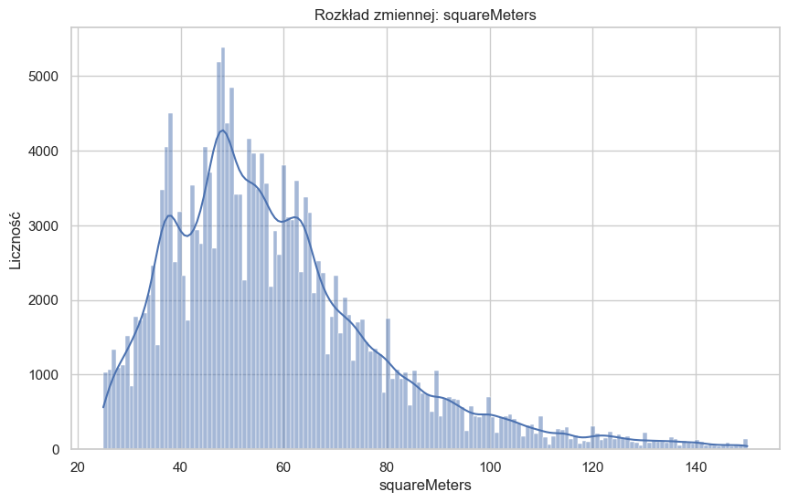

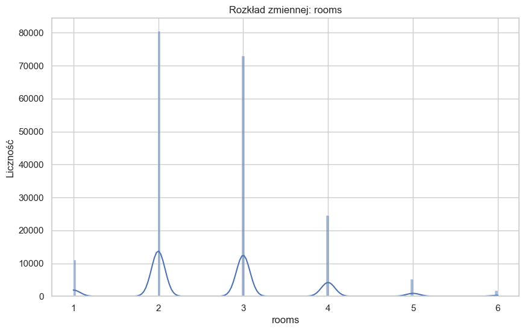

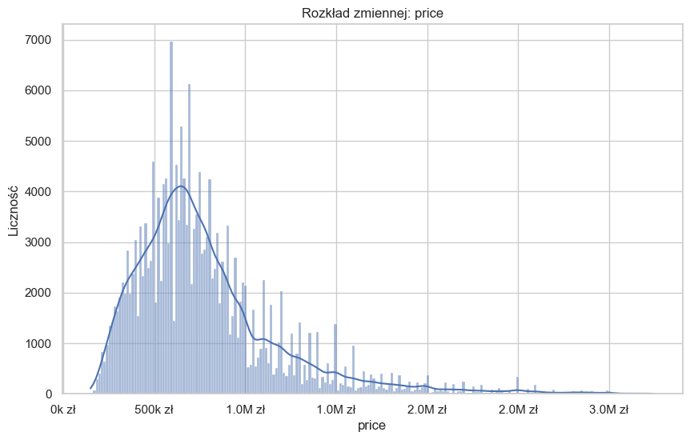

- `squareMeters`: większość mieszkań ma powierzchnię w przedziale 44–68,5 m², a rozkład jest prawoskośny, więc rzadko występują bardzo duże mieszkania.
- `rooms`: dominują mieszkania 2- i 3-pokojowe, co sugeruje, że rynek jest skoncentrowany na ofertach dla małych i średnich gospodarstw domowych.
- `price`: rozkład jest silnie prawoskośny, co oznacza, że większość cen mieści się w średnim zakresie, ale istnieje niewielka grupa znacznie droższych ofert, która podnosi średnią.
- Dodatkowo cena jest umiarkowanie skorelowana z powierzchnią, więc większe mieszkania zwykle kosztują więcej, choć inne cechy również wpływają na wartość.

## Zależność ceny od powierzchni i liczby pokoi

W tej sekcji przedstawiono zależności między ceną a dwiema najważniejszymi zmiennymi numerycznymi: powierzchnią oraz liczbą pokoi. Wykorzystano wykresy punktowe z linią regresji.

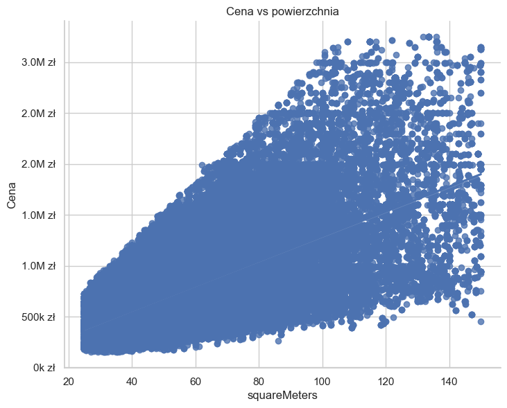

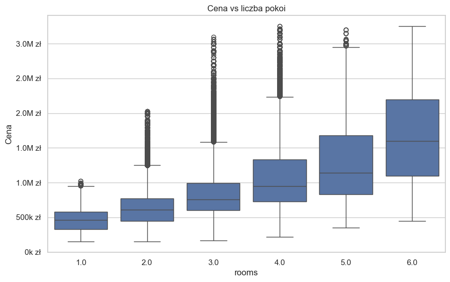

- **Silna relacja liniowa**: wraz ze wzrostem liczby pokoi mediana ceny rośnie systematycznie: 1 pokój ≈ 465 tys. zł, 2 pokoje ≈ 607 tys. zł, 3 pokoje ≈ 760 tys. zł, aż do 6 pokoi ≈ 1,6 mln zł.
- **Korelacja umiarkowana** (r ≈ 0,50) sugeruje, że liczba pokoi jest ważnym, ale nie jedynym czynnikiem determinującym cenę; inne cechy (lokalizacja, warunki, wiek) też mają znaczenie.
- **Efekt ekonomii skali**: chociaż całkowita cena rośnie z liczbą pokoi, cena za metr kwadratowy maleje: mieszkanie 1-pokojowe kosztuje średnio ~15.5 tys. zł/m², a 6-pokojowe tylko ~12.9 tys. zł/m².
- **Zmienność cen wzrasta**: rozrzut cen (odchylenie standardowe) jest większy dla większych mieszkań, co wskazuje na większą heterogeniczność rynku dla apartamentów dużych.

## Różnice cen między miastami

Kolejnym krokiem jest analiza różnic cenowych między miastami. Lokalizacja jest jednym z najważniejszych czynników wpływających na wartość nieruchomości, dlatego porównujemy rozkłady cen w poszczególnych ośrodkach. Ceny mieszkań różnią się istotnie między miastami, co potwierdzono wcześniej testami ANOVA i Kruskal‑Wallisa. Poniższe wykresy przedstawiają rozkład cen w poszczególnych lokalizacjach.

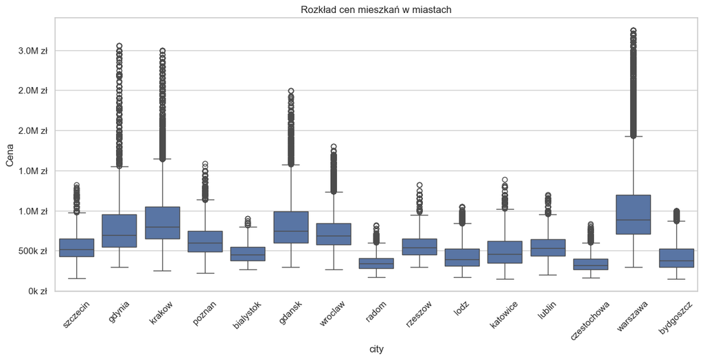

## Różnice cen między typami zabudowy

Oprócz lokalizacji istotnym czynnikiem wpływającym na cenę jest typ zabudowy. W tej sekcji porównujemy ceny mieszkań w zależności od rodzaju budynku: blockOfFlats, tenement oraz apartmentBuilding.

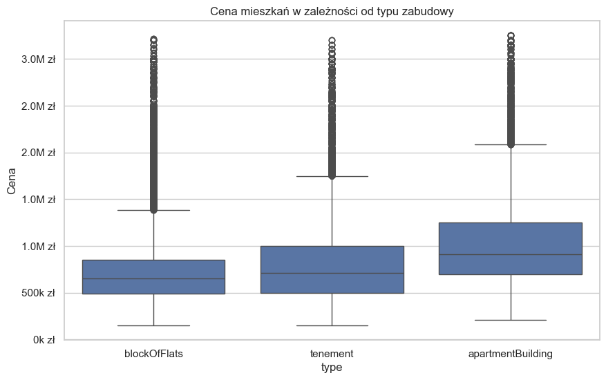

Po analizie przekrojowej przechodzimy do analizy zmian cen w czasie. Pozwala to ocenić dynamikę rynku oraz identyfikować trendy wzrostowe lub stabilizacyjne.

## Trend cen w czasie

Zmienna `month` pozwala ocenić zmiany cen w czasie. W tej sekcji przedstawiono średnie ceny w kolejnych miesiącach.

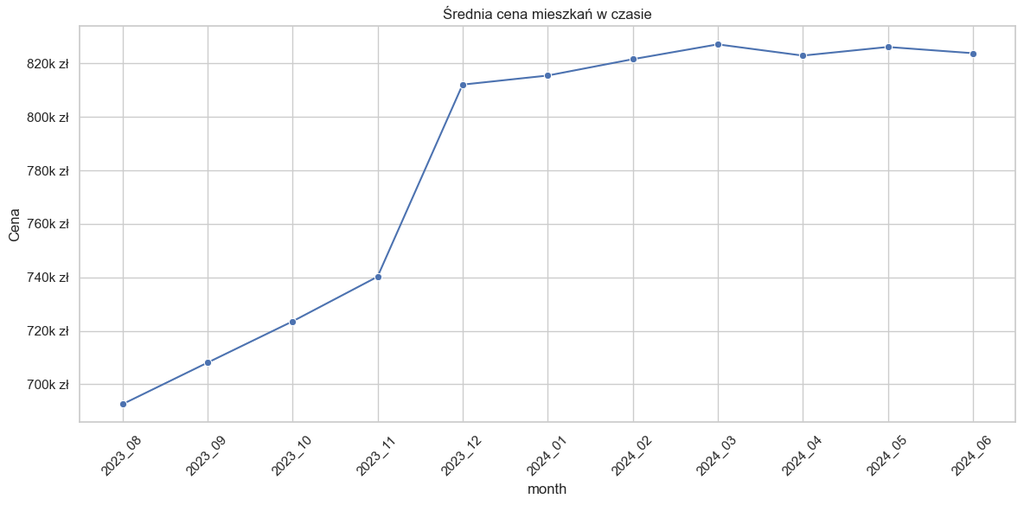

Wykres liniowy przedstawia ewolucję średnich cen mieszkań w kolejnych miesiącach, co umożliwia ocenę kierunku i tempa zmian.

- **Wyraźny trend wzrostu**: od sierpnia 2023 do marca 2024 średnia cena wzrosła o ~19% (z 692,6 tys. zł do 827,2 tys. zł). Wzrost był regularny i konsekwentny.
- **Przyspieszenie w grudniu 2023**: największy skok miał miejsce między listopadem a grudniem (9,7% wzrostu), co może być spowodowane efektem sezonowym lub zmianami na rynku finansowym.
- **Stabilizacja od kwietnia 2024**: od marca ceny przestały rosnąć i oscylują wokół 820-826 tys. zł, co sugeruje zmianę trendu lub osiągnięcie poziomu równowagi rynkowej.

Oprócz analizy cen istotne jest zrozumienie dynamiki podaży. W kolejnej części badamy, jak często ogłoszenia pojawiają się ponownie oraz jak zmieniają się ceny w kolejnych miesiącach.

## Ogłoszenia powtarzające się w czasie

Wizualizacja tego, jak często ogłoszenia pojawiają się w różnych miesiącach, ujawnia, które mieszkania są trudne do sprzedaży i czy sprzedawcy zmieniają strategie cenowe.

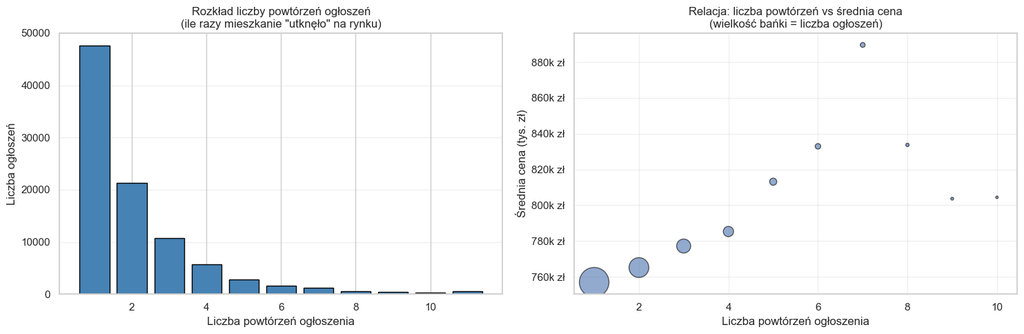

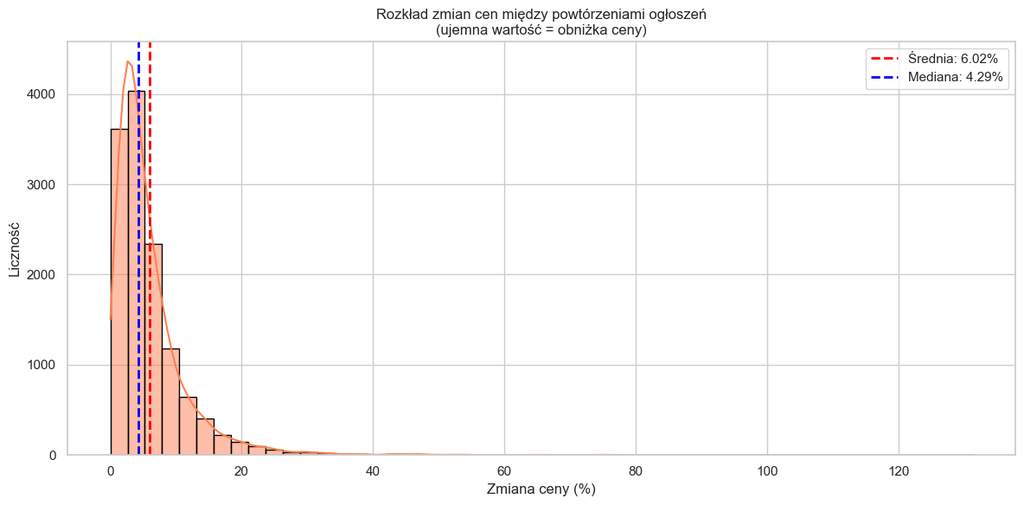

Po analizie podstawowych zależności przechodzimy do bardziej zaawansowanych technik wizualizacji, które pozwalają badać wielowymiarowe relacje oraz złożone struktury danych.

## Zaawansowane wizualizacje — interaktywne i wielowymiarowe

W tej sekcji wykorzystane są bardziej zaawansowane techniki wizualizacji: facety, heatmapy, skale logarytmiczne oraz gęstości dwuwymiarowe. Pozwalają one na jednoczesną analizę wielu wymiarów danych.

### FACET PLOT - Cena vs liczba pokoi w podziale na miasta (top 6)

Aby porównać zależności między ceną a liczbą pokoi w różnych miastach, wykorzystujemy wykresy typu FacetGrid.

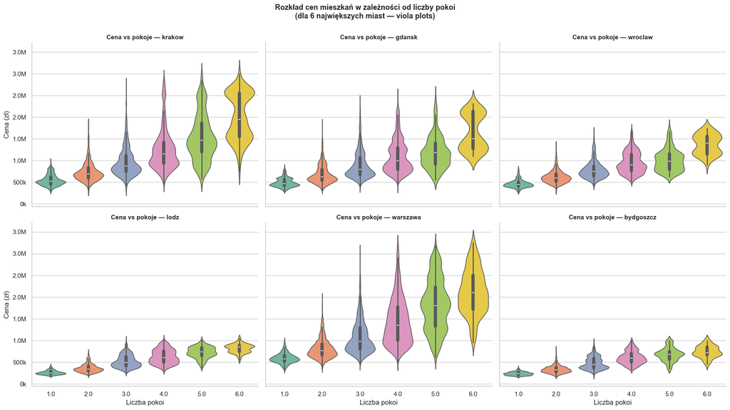

- Facet Plot pokazuje wyraźnie, że te same układy pokoi mają zupełnie inne ceny w różnych miastach — np. 2- i 3-pokojowe mieszkania w Warszawie są znacznie droższe niż w innych top 6 miastach.
- W Warszawie rozkłady są najszersze, co oznacza dużą heterogeniczność rynku; w mniejszych miastach ceny są bardziej skoncentrowane.
- W większości miast 2- i 3-pokojowe mieszkania dominują, ale relacje cenowe różnią się: w niektórych miastach 1-pokojowe oferty mogą być cenowo porównywalne z 2-pokojowymi w innych miastach.
- Facet Plot uwidacznia również różnice w skośności rozkładów — w niektórych miastach ceny są silnie prawoskośne, co sugeruje obecność droższych outlierów.
- Wnioski: lokalizacja ma kluczowe znaczenie dla ceny nawet po uwzględnieniu liczby pokoi, więc model powinien brać pod uwagę interakcje między miastem a liczbą pokoi.

### HEXBIN PLOT - Gęstość ceny vs powierzchnia (ze skalą log dla lepszej widoczności)

Do analizy gęstości punktów w przestrzeni cena–powierzchnia stosujemy wykresy heksagonalne, które dobrze radzą sobie z dużymi zbiorami danych.

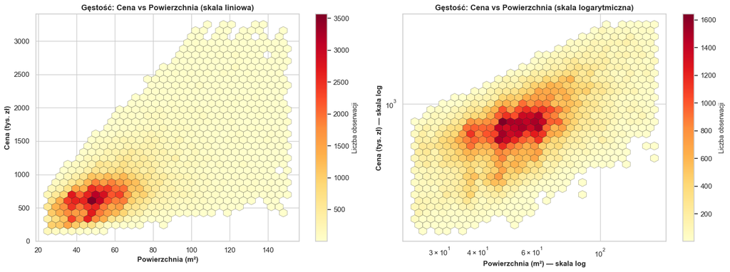

- Gęstość pokazuje, że większość ofert skupia się przy mniejszych mieszkaniach i niższych cenach.
- Skala logarytmiczna ujawnia, że dane nie są ograniczone do jednej masy, a na wykresie pojawiają się rzadsze, droższe/większe oferty.
- Wykres potwierdza, że relacja cena vs powierzchnia jest silna, ale jednocześnie widać dyspersję cen dla tych samych powierzchni.

### VIOLIN PLOT Z PODZIAŁEM - Cena po typach zabudowy vs miasta (top 5)

Wykresy violin pozwalają ocenić pełny rozkład cen w podziale na typ zabudowy i miasto, uwzględniając medianę i kwartyle.

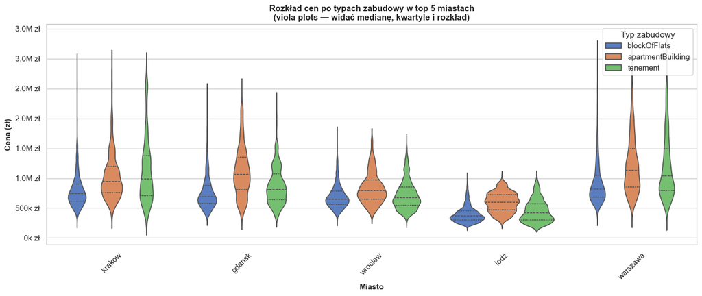

- Apartmentowce mają najwyższą i najszerszą rozpiętość cenową wśród typów zabudowy.
- Bloki są tańsze i bardziej skoncentrowane cenowo, co sugeruje bardziej jednolity segment.
- Kamienice są pośrednie i wykazują umiarkowaną zmienność, co może świadczyć o różnicach lokalizacyjnych i standardowych w tej kategorii.

### BUBBLE CHART - Cena vs pokoje vs powierzchnia (rozmiar bańki = liczba ogłoszeń)

Bubble chart umożliwia jednoczesne porównanie mediany ceny, średniej powierzchni oraz wielkości rynku w poszczególnych miastach.

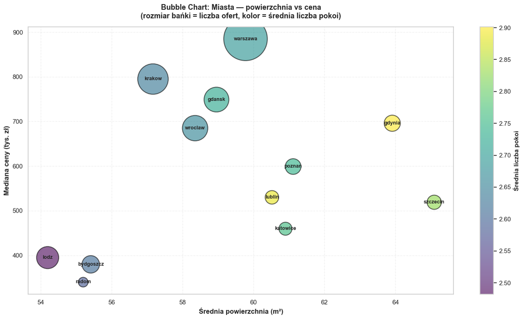

### JOINT PLOT Z KONTOURAMI - Cena vs powierzchnia z marginesowymi histogramami

Joint plot z konturami gęstości pozwala ocenić relację cena–powierzchnia wraz z rozkładami marginalnymi.

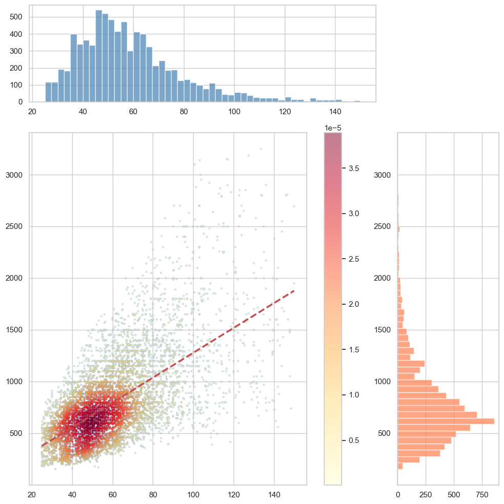

- Joint plot potwierdza, że większość ofert skupia się w dolnym lewym obszarze (mniejsze mieszkania, niższe ceny).
- Marginesowe histogramy pokazują rozkłady powierzchni i cen osobno, co pozwala ocenić ich skośność.
- Linia trendu wskazuje, że relacja cena-powierzchnia jest silna, a rzadkie przypadki dużych mieszkań o niskich cenach są wyraźnymi outlierami.

### STACKED AREA CHART - Trend liczby ofert po typach zabudowy w czasie

Wykres obszarowy przedstawia zmiany liczby ofert w czasie z podziałem na typy zabudowy, co pozwala ocenić stabilność struktury podaży.

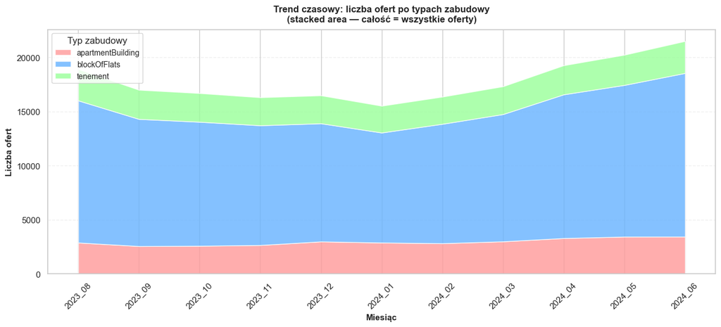

Wizualizacje pozwoliły zrozumieć strukturę i dynamikę rynku mieszkaniowego. Analiza rozkładów zmiennych numerycznych ujawniła silną prawoskośność cen oraz powierzchni, co wskazuje na obecność niewielkiej grupy mieszkań o bardzo wysokich wartościach. Zależności między ceną a kluczowymi cechami — powierzchnią i liczbą pokoi — okazały się wyraźne, choć nieliniowe, a zmienność cen rośnie wraz z wielkością mieszkań.

Porównanie cen między miastami potwierdziło silne zróżnicowanie regionalne, z wyraźną dominacją Warszawy i dużych ośrodków metropolitalnych. Typ zabudowy również okazał się istotnym czynnikiem — apartamentowce tworzą segment premium, podczas gdy bloki stanowią podstawę rynku o niższych cenach jednostkowych.

Zaawansowane wizualizacje — facety, hexbiny, wykresy violin, bubble charts i joint plots — pozwoliły uchwycić wielowymiarowe zależności, w tym interakcje między lokalizacją, typem zabudowy, liczbą pokoi i ceną. Wskazują one jednoznacznie, że rynek mieszkaniowy jest silnie heterogeniczny, a kluczowe determinanty ceny działają w sposób złożony i zależny od kontekstu.

Podsumowując, wizualizacje potwierdziły najważniejsze wnioski analityczne: cena mieszkań jest determinowana przede wszystkim przez lokalizację, powierzchnię, typ zabudowy oraz dynamikę rynku w czasie. Wyniki te stanowią solidną podstawę do dalszych etapów pracy, w szczególności modelowania cen i identyfikacji czynników wpływających na wartość nieruchomości.

# 5. Wnioski

Przeprowadzona analiza danych mieszkaniowych obejmująca etapy wczytywania, czyszczenia, analizy opisowej oraz wizualizacji pozwoliła uzyskać pełny obraz struktury, dynamiki i zróżnicowania rynku nieruchomości w Polsce w okresie od sierpnia 2023 do czerwca 2024. Poniżej przedstawiono najważniejsze wnioski wynikające z całego procesu badawczego.

## 1) Jakość i struktura danych

Dane źródłowe okazały się spójne pod względem liczby kolumn i struktury, co umożliwiło ich bezproblemowe połączenie w jeden zbiór obejmujący ponad 195 tys. obserwacji. Występowanie powtarzających się identyfikatorów ofert było zjawiskiem naturalnym i oczekiwanym — wiele mieszkań pojawiało się w kolejnych miesiącach, co odzwierciedla realną dynamikę rynku.

Proces czyszczenia danych pozwolił na usunięcie jednej zmiennej oraz imputację pozostałych braków z wykorzystaniem metod dopasowanych do mechanizmów braków (MCAR/MAR). Zastosowanie IterativeImputer umożliwiło spójną i wielowymiarową imputację zmiennych odległościowych. Ostatecznie uzyskano kompletny, wysokiej jakości zbiór danych gotowy do dalszej analizy.

## 2) Charakterystyka rynku mieszkaniowego

Analiza opisowa wykazała, że rynek mieszkaniowy jest silnie zróżnicowany pod względem powierzchni, liczby pokoi, roku budowy oraz lokalizacji. Rozkłady zmiennych numerycznych były w większości prawoskośne, co wskazuje na obecność niewielkiej liczby mieszkań o bardzo dużych powierzchniach lub wysokich cenach.

## 3) Znaczenie lokalizacji i typu zabudowy

Lokalizacja okazała się kluczowym czynnikiem wpływającym na cenę. Warszawa, Kraków i Gdańsk tworzą wyraźnie wyodrębniony segment premium, podczas gdy miasta średnie i mniejsze charakteryzują się niższymi i bardziej stabilnymi cenami. Testy ANOVA i Kruskal–Wallisa jednoznacznie potwierdziły istotne statystycznie różnice między miastami.

Typ zabudowy również odgrywa istotną rolę: apartamentowce są najdroższe, bloki najtańsze, a kamienice zajmują pozycję pośrednią. Różnice te wynikają zarówno z lokalizacji, jak i standardu budynków.

## 4) Trendy czasowe

Analiza zmian cen w czasie wykazała wyraźny trend wzrostowy od sierpnia 2023 do marca 2024, z największym przyspieszeniem w grudniu. Od kwietnia 2024 ceny ustabilizowały się, co może sugerować osiągnięcie równowagi rynkowej lub reakcję rynku na zmiany makroekonomiczne.

## 5) Dynamika ogłoszeń i trudność sprzedaży

Prawie połowa ogłoszeń (48,8%) pojawia się wielokrotnie, co wskazuje na trudności w sprzedaży części mieszkań. Najczęściej ogłoszenia powtarzają się 2–3 razy, ale istnieje grupa ofert „utkniętych” na rynku nawet przez 11 miesięcy.

## 6) Złożone zależności i heterogeniczność rynku

Zaawansowane wizualizacje (facet plots, hexbiny, violin plots, bubble charts, joint plots) ujawniły wielowymiarowe zależności między ceną, powierzchnią, liczbą pokoi, lokalizacją i typem zabudowy. Rynek mieszkaniowy jest silnie heterogeniczny, a kluczowe determinanty ceny działają w sposób nieliniowy i zależny od kontekstu.

## 7) Podsumowanie ogólne

Całość przeprowadzonej analizy wskazuje, że:

- cena mieszkań zależy przede wszystkim od lokalizacji, powierzchni i typu zabudowy,
- rynek charakteryzuje się dużą zmiennością i segmentacją,
- część mieszkań jest trudna do sprzedaży, co odzwierciedlają powtarzające się ogłoszenia,
- trendy cenowe w ostatnich miesiącach wskazują na dynamiczny wzrost, a następnie stabilizację,
- przygotowany zbiór danych jest kompletny i stanowi solidną podstawę do dalszych etapów pracy, w szczególności modelowania cen oraz analizy czynników wpływających na wartość nieruchomości.

Wnioski te tworzą spójny obraz rynku mieszkaniowego i stanowią fundament do budowy modeli predykcyjnych oraz dalszych badań analitycznych.